# Exploratory Analysis

## College enrollment data: An analysis on the enrollment statistics of colleges in the US

### Authors

| Name | Email |
| --- | --- |
| Bonnie Chen | bonche22@uw.edu |
| Ling Lin | lingl3@uw.edu. |
| Yuchen An | ayc0816@uw.edu. |
| Mandy Wu | rwu1@uw.edu |

### Date

February 20, 2023 (Winter 2023)

### Abstract

Our project will attempt to analyze the data of college institutions in the US, including factors such as their enrollment size, acceptance rate, graduation rates, student demographic, etc. Through this, we can unveil the patterns of college enrollments based on different factors and show they shape the higher education system.

### Keywords

Keywords: Higher education, college admissions, students

### Introduction

Our research study aims to examine the various factors that influence college admissions in the United States. The college admission process is a critical issue for students, educators, and policy makers, as it has a significant impact on a student’s future success and well-being. The study will focus on exploring the role of student demographics, academic performance, standardized test scores, and extracurricular activities in the admissions process. By examining these factors, the study aims to uncover trends and patterns in the admissions process and contribute to the ongoing conversation about accessibility and equity in higher education. The findings of this study will provide valuable information for students, educators, and policy makers, as they work to ensure that all students have equal opportunities to pursue higher education and achieve their full potential.

**Research questions:**

- How does a student’s identity (race, gender, socioeconomic status) impact their access to higher education?
- What is the demographic composition of college students in the US and how has it changed over time?
- How does the graduation rate of colleges vary?
- How has the enrollment rates of higher education changed over time?

Studying the impact of a student’s identity, including factors such as race, gender, and socioeconomic status, on their access to higher education is crucial for promoting diversity and inclusion and ensuring equal opportunities for all students. The demographics of college students have an impact on the types of programs and services that institutions offer and the types of support they provide. By understanding demographic trends in college enrollment, graduation rates, and other key metrics, decision-makers can make informed decisions about investment in higher education and workforce development.

For example, by examining the graduation rates of different demographic groups, it is possible to identify any disparities and target efforts to improve educational outcomes for underrepresented groups. Furthermore, understanding the demographic composition of college students and how it has changed over time can provide insight into the progress made in promoting diversity and inclusion in higher education.

Overall, the study of the impact of a student’s identity on access to higher education is important for promoting equity and ensuring that all students have the opportunity to succeed. The information gathered from this type of research can inform decisions and policies aimed at improving access to and success in higher education for all students, regardless of their background.

### Related Work

College admission is getting more and more competitive, especially in 2022. Due to the outbreak of Covid-19, a record number of students have chosen to send college deferral letters and take a gap year. After the Covid-19 pandemic starts slowing down, students who left college during Covid-19 want to return school. The recruitment of new students, waitlisted students, college deferrals, transfer students, and international students arouse public attention. At this time, many schools adopted test-optional policies and the elimination of SAT or ACT subject test leading to an influx college applicant, with Common App experiencing a 22% surge in total applications submitted for class of 2026. Therefore, our project aims at studying data of college institutions and trying to find out what factors would influence the college admissions.

In a study titled *[College Enrollment & Student Demographic Statistics](https://educationdata.org/college-enrollment-statistics)*, College enrollment totaled 15.85 million undergraduate students nationwide in fall 2020, a 4.31% decline year-over-year. 14.08 million college students attend 4-year institutions in fall Postsecondary Enrollment 2022. 73.7% of all postsecondary students attend public institutions and 27.0% of postsecondary students attend private institutions. Among all students, Black and Hispanic students enroll in higher numbers in community colleges and less-selective four-year institutions. However, 76.4% of White or Caucasian students enroll at 4-year institutions.

In an additional study titled *[Race and gender differences in how sense of belonging influences decisions to major in STEM](https://stemeducationjournal.springeropen.com/articles/10.1186/s40594-018-0115-6)*, the reason why women and students of color are widely underrepresented in most STEM fields is that students from underrepresented groups are less likely to feel they belong to STEM, like computer science or engineering. According to the survey, there are four key factors that were found to contribute to a sense of belonging: interpersonal relationships, perceived competence, personal interest, and science identity. However, due to the structural and cultural features of many universities, as well as STEM curricula and pedagogy, it seems like white males are privileged.

A third article titled *[More student or faculty diversity on campus leads to lower racial gaps in graduation rates](https://theconversation.com/more-student-or-faculty-diversity-on-campus-leads-to-lower-racial-gaps-in-graduation-rates-181924)* shows that if there are more students of color or faculty of color on campus, the graduation gap between Black and white students tends to shrink. In schools where 5% of the student body is Black, research shows white students are 16% more likely than Black students to graduate. In colleges where 65% of the students are Black, white students are only 4% more likely to graduate than Black students. All of these studies are closely related with our topic for the project and show us that there are many factors involved in college admission.

**References:**

Nicholas A. Bowman Mary Louise Petersen Chair in Higher Education. (2022, September 13). More student or faculty diversity on campus leads to lower racial gaps in graduation rates. The Conversation. Retrieved February 3, 2023, from https://theconversation.com/more-student-or-faculty-diversity-on-campus-leads-to-lower-racial-gaps-in-graduation-rates-181924

Hanson, M., & Checked, F. (2023, January 1). College enrollment statistics [2023]: Total + by demographic. Education Data Initiative. Retrieved February 3, 2023, from https://educationdata.org/college-enrollment-statistics

Rainey, K., Dancy, M., Mickelson, R., Stearns, E., & Moller, S. (2018, April 10). Race and gender differences in how sense of belonging influences decisions to major in STEM - International Journal of STEM Education. SpringerOpen. Retrieved February 3, 2023, from https://stemeducationjournal.springeropen.com/articles/10.1186/s40594-018-0115-6

### The Dataset

The data set we chose to use is [College Admissions](https://www.kaggle.com/datasets/samsonqian/college-admissions). The data set was found by using Google Data Search. It was collected and created by [Kaggle](https://www.kaggle.com), an online community of data scientists and machine learning practitioners founded in 2010.

The data is collected by Samson Qian, a masters student in Financial Engineering at MIT, to share information about colleges in the US. The data includes information like the student demographic composition, enrollment and application statistics, standardized test scores, graduation rates, etc. for each college in the US. However, there was no clear indication of how the data was sourced.

A possible problem with this data is the source for this data. The data was created four years ago, but there are no citations on where this information was collected from and no time stamp on the time that this data was sourced. Even though the creator of the data set has a credible background, a lack of transparency in where the data of sourced makes the data set a little skeptical to work with.

A limitation of this data set is that even though it has many columns with very specific information for each institution, it does not provide a comprehensive look into the institutions. For example, the data set only includes information on federal financial aid provided to freshman students, but doesn’t have data for such statistics for students in other years, which prevents us from analyzing how factors like that may differ for different demographic groups.

### Implications

Assuming we answer our research questions, possible implications for technologists can be configuring the system to support the pursuit of higher education. Currently, the college application process is complicated and requires students to fulfill many different components, and not all students have equal resources to successfully complete the requirements. Technologists can reimagine a way to centralize the application process to make it easier for underprivileged students to access.

Possible implications for designers could be redesigning the systems used for college applications and admissions to account for more variety in its applicant pools and reduce potential prejudice in evaluating applicants. Perhaps the interface can be designed in a more human-centered way and allows students to showcase qualities beyond their grades and extracurriculars.

Possible implications for policymakers could be proposing policies that minimize discrimination in the college admission process and protect student privacy. For instance, should students need to provide information such as their race, gender, disability status, and how does that reinforce the inequality that applicants may face? Policies can be made to put restrictions on how much data colleges should have access to to ensure a more impartial selection in a school’s student body.

### Limitations & Challenges

Some limitations we may need to address are data that might be missing or miscalculated if students are applying to or attending colleges through other pathways, such as special educational programs or athletic endorsements. Because our project is trying to analyze how different factors play into the role of college admissions, we are examining data that represents students who applied to college through the traditional route.

A challenge we may run into is finding comprehensive data that align with our research direction. Certain information about a college’s student admissions can be a breach of privacy, therefore we may not find the information we are seeking available to the public. In addition, we are trying to examine the discriminatory behavior within the higher education system, specifically during the admissions process, and that information is also unlikely to be available to the public. Thus, we will have to find related data that is available and use them to make inferences to answer our research questions.

### Summary Information

There are in total of 108 columns and 1534 rows in the data frame where each row represents a university unit. For the enrollment data, we have 157 of NA value which are not collected. The data are collected across 51 states and there are 1436275 enrollments recorded in total. The enrollment has a mean of 1043.05 while the min enrollment is 0 and max enrollment is 10241.

### Table

```
## # A tibble: 51 × 3
##    State.abbreviation total_enrollment avg_tuition
##    <chr>                         <int>       <dbl>
##  1 California                   120777      23476.
##  2 New York                     111033      24376.
##  3 Texas                         93767      16346.
##  4 Pennsylvania                  85880      25373.
##  5 Ohio                          57073      23018.
##  6 Florida                       56893      18074.
##  7 Illinois                      50238      25162.
##  8 Michigan                      49623      17164.
##  9 Massachusetts                 49576      30859.
## 10 North Carolina                48095      20099.
## # … with 41 more rows
```

When we group the university enrollment by state, we are essentially taking a large data set of university enrollment information and grouping it together based on the state in which each university is located. This allows us to see aggregate information about university enrollment for each state, rather than viewing the enrollment information for each individual university separately. By grouping the data in this way, we can gain insights into patterns and trends in university enrollment across different states.

### Chart 1

I chose to use the map to show that the number of undergraduate enrollment grouped by state boundaries. I wanted to show the difference of college student population throughout the country, and then found states with the most college students and states with lowest college students.

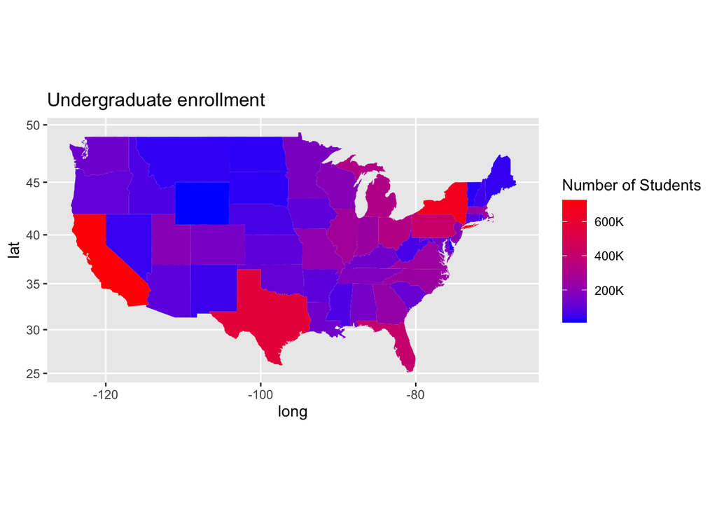

### Chart 2

I chose to create this pie chart to present the undergrad enrollment percentage by geography location to find out what are the places (location) that undergrad students like the most and analyze how the geography location affects the enrollment of universities.

The piechart shows that the top three ranking of geography location that has the most undergrad enrollment are city: large, city: small, and suburb: large, in which most of the students chose the university that is in or close to the city, and this might mean that university that is in or near the city usually has a higher number of student enrollments than others.

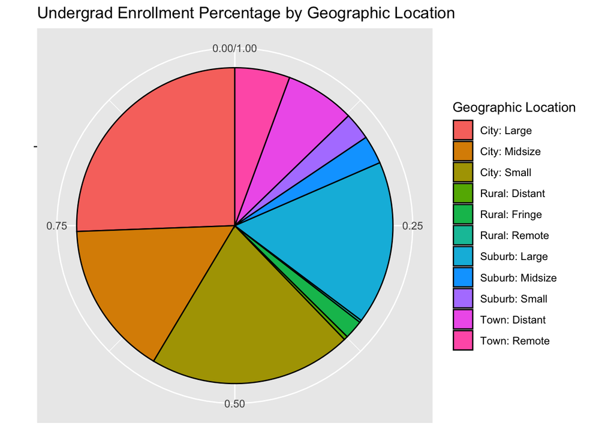

### Chart 3

I chose to create this chart to analyze the correlation between a college’s acceptance rate and 4-year graduation rate to analyze whether the selectivity of an institution has an impact on the success of their students to graduate on time. I also added a differentiation for private versus public institutions to show whether more selective colleges are generally public or private.

After creating the chart, it reveals that there is a slight correlation between the two factors. The most selective colleges are almost all private institutions, and they tend to have a higher graduation rate. However, there are also a handful of data points that show selective institutions that have a lower 4-year graduation rate. Lastly, the chart shows that most colleges tend to fall between a 50-80% acceptance rate with a 4-year graduation rate between 15-50%.

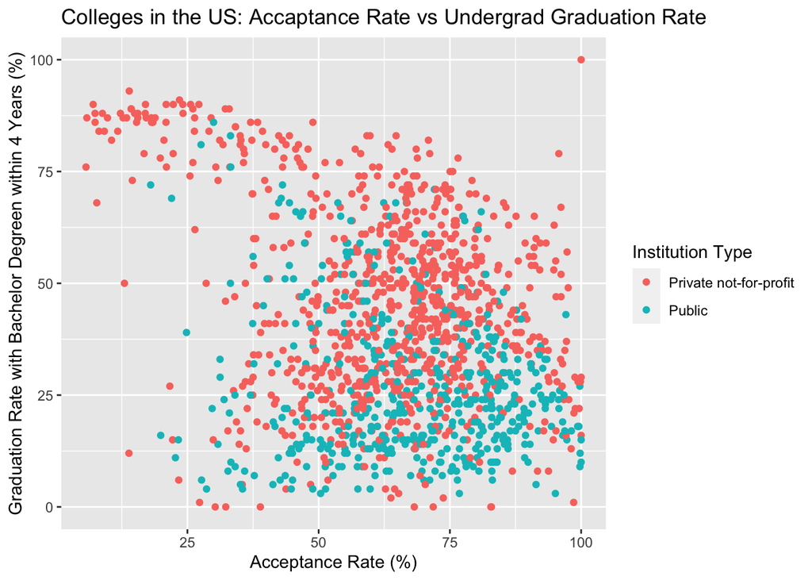